[figure not shown]

# Algorithmes [OSMnx](https://geoffboeing.com/2016/11/osmnx-python-street-networks/) pour visualiser et analyser le réseau routier des principales villes françaises en modélisant les réseaux de transport, en calculant les statistiques et l'orientation moyenne avec les données d'[OpenStreetMap](https://www.openstreetmap.org/#map=11/10.5061/-66.9146) et de l'API [GoogleMaps](https://developers.google.com/maps/documentation/elevation/intro?hl=es-419).

[Roque Leal](https://roqueleal.me)

87% des trajets s’effectuent sur les routes. Élément essentiel du maillage territorial, pour cette raison, nous étudierons le nouveaux algorithmes comme OSMnx nous présentent une série d'indicateurs qui aident à définir la logique spatiale et l'ordre urbain, révélant l'ordre et le désordre des rues, ainsi que les meilleures stratégies pour la dynamique du transport d'une ville. Dans cette opportunité, nous explorerons la ville de Paris en utilisant les données d'OpenStreetMap et OSMnx dans une première occasion de connaître le réseau routier et d'exécuter une modélisation des itinéraires basée sur les distances et l'impédance et enfin d'appliquer l'indicateur d'orientation des villes afin de quantifier la façon dont les réseaux routiers dans les villes françaises suivent une logique d’ordonnancement géométrique d’une grille unique ou son schéma est hétérogène.

## Les ressources:

1.- Données de l'API OpenStreetMap pour télécharger des données depuis le réseau routier.

2.- Données Google Maps API pour télécharger les données d'altitude et les associer au réseau routier, pour développer notre modèle d'impédances, défini par la différence d'altitude des itinéraires.

3.- Appliquer l'algorithme OSMnx pour développer les modèles et définir les directions cardinales des axes routiers.

## Sources

```python
from api import APIKey
import networkx as nx
import numpy as np
import osmnx as ox
import matplotlib.pyplot as plt
import pandas as pd
%matplotlib inline
import datetime
import pandas as pd
weight_by_length = False
ox.__version__
ox.config(log_console=True, use_cache=True)
ox.__version__
```

```
'0.11.4'
```

```python
# Nous extrayons les données associées à Paris
place = 'Paris'
place_query = {'city':'Paris', 'state':'Paris', 'country':'France'}
G = ox.graph_from_place(place_query, network_type='drive')
```

```python
# Nous consultons les données de chaque nœud routier extrait à l'aide des données de l'API Google Elevation
G = ox.add_node_elevations(G, api_key=APIKey)
G = ox.add_edge_grades(G)
```

## Nous calculons les variations de la pente du réseau routier

Nous utilisons les nœuds pour définir le réseau et nous prenons uniquement les valeurs uniques pour éviter de dupliquer les données et enfin calculer les valeurs de pourcentage de pente.

```python
edge_grades = [data['grade_abs'] for u, v, k, data in ox.get_undirected(G).edges(keys=True, data=True)]
```

```python
avg_grade = np.mean(edge_grades)
print('Pente moyenne du réseau routier à Paris  {} is {:.1f}%'.format(place, avg_grade*100))

med_grade = np.median(edge_grades)
print('Pente médiane du réseau routier à Paris {} is {:.1f}%'.format(place, med_grade*100))
```

```
Pente moyenne du réseau routier à Paris  Paris is 1.5%
Pente médiane du réseau routier à Paris Paris is 1.0%
```

Nous voyons qu'en moyenne la ville de Paris a une condition idéale pour le développement d'une infrastructure pour Ciclovia, maintenant nous allons visualiser le réseau développant un modèle d'impédance en raison de l'état des distances et de la différence d'altitude.

## Visualiser les nœuds routiers et leur altitude

Ce sont les valeurs du violet de basse altitude et celles du jaune de plus haute altitude.

```python
G_proj = ox.project_graph(G)
```

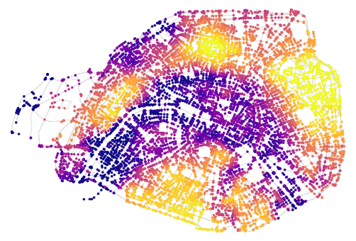

```python
nc = ox.get_node_colors_by_attr(G_proj, 'elevation', cmap='plasma', num_bins=20)
fig, ax = ox.plot_graph(G_proj, fig_height=6, node_color=nc, node_size=12, node_zorder=2, edge_color='#dddddd')
```

## Les valeurs d'altitude sont intégrées au réseau routier français pour visualiser notre modèle d'impédance

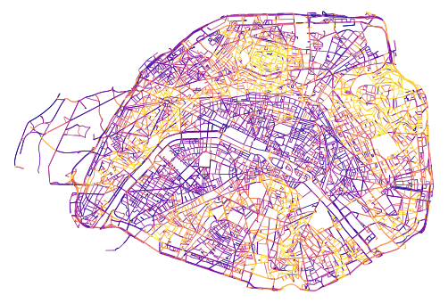

```python
# Nous cartographions le réseau routier avec les valeurs d'altitude téléchargées
ec = ox.get_edge_colors_by_attr(G_proj, 'grade_abs', cmap='plasma', num_bins=100)
fig, ax = ox.plot_graph(G_proj, fig_height=6, edge_color=ec, edge_linewidth=0.8, node_size=0)
```

## Nous exécutons le modèle d'impédance définissant un itinéraire pour calculer l'itinéraire le plus court et l'itinéraire avec la pente la plus basse

```python
# sélectionnez un nœud d'origine et de destination et un cadre de sélection autour d'eux
origin = ox.get_nearest_node(G, (48.826955,2.366481))
destination = ox.get_nearest_node(G, (48.890483,2.337470))
bbox = ox.bbox_from_point((48.859661,2.333608), distance=5000, project_utm=True)
```

```python
# Nous définissons notre modèle en fonction des variations de distance et de pente
def impedance(length, grade):
    penalty = grade ** 2
    return length * penalty


for u, v, k, data in G_proj.edges(keys=True, data=True):
    data['impedance'] = impedance(data['length'], data['grade_abs'])
    data['rise'] = data['length'] * data['grade']
```

#### Itinéraire le plus court:

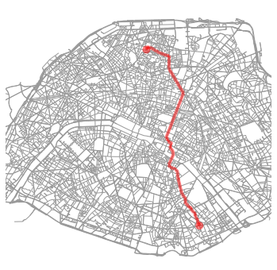

```python
route_by_length = nx.shortest_path(G_proj, source=origin, target=destination, weight='length')
fig, ax = ox.plot_graph_route(G_proj, route_by_length, bbox=bbox, node_size=0)
```

#### Route avec moins de pente:

[figure not shown]

```python
route_by_impedance = nx.shortest_path(G_proj, source=origin, target=destination, weight='impedance')
fig, ax = ox.plot_graph_route(G_proj, route_by_impedance, bbox=bbox, node_size=0)
```

#### Calculons les statistiques pour les deux routes:

```python
def print_route_stats(route):
    route_grades = ox.get_route_edge_attributes(G_proj, route, 'grade_abs')
    msg = 'la pente moyenne est {:.1f}% et le max est {:.1f}%'
    print(msg.format(np.mean(route_grades)*100, np.max(route_grades)*100))

    route_rises = ox.get_route_edge_attributes(G_proj, route, 'rise')
    ascent = np.sum([rise for rise in route_rises if rise >= 0])
    descent = np.sum([rise for rise in route_rises if rise < 0])
    msg = 'Le changement altitudinal total est {:.0f} mètres: {:.0f} mètres dans ascension et {:.0f} mètres descente'
    print(msg.format(np.sum(route_rises), ascent, abs(descent)))

    route_lengths = ox.get_route_edge_attributes(G_proj, route, 'length')
    print('Distance totale du trajet: {:,.0f} mètres'.format(np.sum(route_lengths)))
```

### Statistiques sur les itinéraires les plus courts

```python
print_route_stats(route_by_length)
```

```
la pente moyenne est 2.0% et le max est 21.3%
Le changement altitudinal total est 19 mètres: 83 mètres dans ascension et 64 mètres descente
Distance totale du trajet: 8,963 mètres
```

### Statistiques pour l'itinéraire avec la pente la plus basse

```python
print_route_stats(route_by_impedance)
```

```
la pente moyenne est 0.9% et le max est 6.0%
Le changement altitudinal total est 19 mètres: 63 mètres dans ascension et 43 mètres descente
Distance totale du trajet: 14,642 mètres
```

# L'ordre spatial urbain: orientation du réseau routier dans les villes françaises

## Villes françaises

```python
places = {'Paris'       : 'Paris, France',
         'Rennes'        : 'Rennes, France',
         'Lyon'       : 'Lyon, France',
         'Reims'     : 'Reims, France',
         'Le Havre'       : 'Le Havre, France',
         'Marseille'     : 'Marseille, France',
         'Saint-Étienne'        : 'Saint-Étienne, France',
         'Toulon'       : 'Toulon, France',
         'Toulouse'        : 'Toulouse, France',
         'Grenoble'       : 'Grenoble, France',
         'Nice'     : 'Nice, France',
         'Dijon'     : 'Dijon, France',
         'Nantes'         : 'Nantes, France',
         'Strasbourg'   : 'Strasbourg, France',
         'Nîmes'       : 'Nîmes, France',
         'Angers'  : 'Angers, France',
         'Villeurbanne'       : 'Villeurbanne, France',
         'Le Mans'      : 'Le Mans, France',
         'Saint-Denis'    : 'Saint-Denis, France',
         'Montpellier' : {'city':'Montpellier', 'state':'Occitanie', 'country':'France'},
         'Aix-en-Provence'       : 'Aix-en-Provence, France',
         'Clermont-Ferrand'      : 'Clermont-Ferrand, France',
         'Brest'         : 'Brest, France',
         'Lille'    : 'Lille, France'}
```

```python
gdf = ox.gdf_from_places(places.values())
gdf
```

|  | geometry | place_name | bbox_north | bbox_south | bbox_east | bbox_west |
| --- | --- | --- | --- | --- | --- | --- |
| 0 | POLYGON ((2.22412 48.85420, 2.22412 48.85402, ... | Paris, Ile-de-France, Metropolitan France, France | 48.902156 | 48.815576 | 2.469760 | 2.224122 |
| 1 | POLYGON ((-1.75259 48.08765, -1.75254 48.08740... | Rennes, Ille-et-Vilaine, Brittany, Metropolita... | 48.154970 | 48.076915 | -1.624405 | -1.752588 |
| 2 | POLYGON ((4.77181 45.75103, 4.77182 45.75102, ... | Lyon, Métropole de Lyon, Departemental constit... | 45.808263 | 45.707367 | 4.898377 | 4.771813 |
| 3 | POLYGON ((3.98582 49.29335, 3.98924 49.29150, ... | Reims, Marne, Grand Est, Metropolitan France, ... | 49.303187 | 49.203935 | 4.129696 | 3.985821 |
| 4 | POLYGON ((0.06680 49.51855, 0.06965 49.51801, ... | Le Havre, Seine-Maritime, Normandy, Metropolit... | 49.540146 | 49.451670 | 0.195556 | 0.066799 |
| 5 | MULTIPOLYGON (((5.22863 43.19774, 5.22864 43.1... | Marseille, Provence-Alpes-Côte d'Azur, Metropo... | 43.391033 | 43.169623 | 5.532476 | 5.228631 |
| 6 | MULTIPOLYGON (((4.24430 45.43680, 4.24432 45.4... | Saint-Étienne, Loire, Auvergne-Rhône-Alpes, Me... | 45.476708 | 45.371539 | 4.488858 | 4.244297 |
| 7 | MULTIPOLYGON (((5.87950 43.13422, 5.87963 43.1... | Toulon, Var, Provence-Alpes-Côte d'Azur, Metro... | 43.171494 | 43.102041 | 5.987384 | 5.879503 |
| 8 | POLYGON ((1.35040 43.60427, 1.35164 43.60390, ... | Toulouse, Haute-Garonne, Occitania, Metropolit... | 43.668708 | 43.532654 | 1.515380 | 1.350396 |
| 9 | POLYGON ((5.67761 45.21287, 5.68481 45.20761, ... | Grenoble, Isère, Auvergne-Rhône-Alpes, Metropo... | 45.214076 | 45.154144 | 5.753118 | 5.677606 |
| 10 | POLYGON ((7.18195 43.73746, 7.18202 43.73625, ... | Nice, Maritime Alps, Provence-Alpes-Côte d'Azu... | 43.760764 | 43.645419 | 7.323912 | 7.181953 |
| 11 | POLYGON ((4.96246 47.32499, 4.96258 47.32494, ... | Dijon, Côte-d'Or, Bourgogne-Franche-Comté, Met... | 47.377486 | 47.286247 | 5.102060 | 4.962459 |
| 12 | POLYGON ((-1.64181 47.19116, -1.64174 47.19086... | Nantes, Loire-Atlantique, Pays de la Loire, Me... | 47.295858 | 47.180586 | -1.478844 | -1.641811 |
| 13 | POLYGON ((7.68814 48.59947, 7.68826 48.59812, ... | Strasbourg, Bas-Rhin, Grand Est, Metropolitan ... | 48.646190 | 48.491861 | 7.836065 | 7.688137 |
| 14 | POLYGON ((4.23567 43.86511, 4.23787 43.86022, ... | Nimes, Nîmes, Gard, Occitania, Metropolitan Fr... | 43.923018 | 43.741266 | 4.449661 | 4.235671 |
| 15 | POLYGON ((-0.61769 47.46008, -0.61769 47.46005... | Angers, Maine-et-Loire, Pays de la Loire, Metr... | 47.526299 | 47.437355 | -0.508563 | -0.617693 |
| 16 | POLYGON ((4.85836 45.77243, 4.86034 45.77197, ... | Villeurbanne, Lyon, Métropole de Lyon, Departe... | 45.795588 | 45.748452 | 4.921261 | 4.858362 |
| 17 | POLYGON ((0.13628 48.01766, 0.13629 48.01764, ... | Le Mans, Sarthe, Pays de la Loire, Metropolita... | 48.035873 | 47.927977 | 0.255094 | 0.136283 |
| 18 | POLYGON ((2.33322 48.92317, 2.33681 48.92109, ... | Saint-Denis, Seine-Saint-Denis, Ile-de-France,... | 48.952135 | 48.901493 | 2.398118 | 2.333219 |
| 19 | POLYGON ((3.80706 43.63465, 3.80711 43.63450, ... | Montpellier, Hérault, Occitania, Metropolitan ... | 43.653358 | 43.566709 | 3.941321 | 3.807060 |
| 20 | POLYGON ((5.26947 43.49617, 5.26952 43.49567, ... | Aix-en-Provence, Provence-Alpes-Côte d'Azur, M... | 43.625922 | 43.446106 | 5.506301 | 5.269475 |
| 21 | POLYGON ((3.05326 45.78583, 3.05331 45.78577, ... | Clermont-Ferrand, Puy-de-Dôme, Auvergne-Rhône-... | 45.818384 | 45.755694 | 3.172176 | 3.053256 |
| 22 | POLYGON ((-4.56892 48.39279, -4.56876 48.39266... | Brest, Finistère, Brittany, Metropolitan Franc... | 48.459552 | 48.357297 | -4.427831 | -4.568917 |
| 23 | POLYGON ((2.96797 50.63509, 2.96960 50.63359, ... | Lille, Nord, Hauts-de-France, Metropolitan Fra... | 50.661260 | 50.600826 | 3.125725 | 2.967968 |

## Obtenez les réseaux routiers et leurs repères

```python
def reverse_bearing(x):
    return x + 180 if x < 180 else x - 180
```

```python
bearings = {}
for place in sorted(places.keys()):
    print(datetime.datetime.now(), place)


    query = places[place]
    G = ox.graph_from_place(query, network_type='drive')


    Gu = ox.add_edge_bearings(ox.get_undirected(G))

    if weight_by_length:

        city_bearings = []
        for u, v, k, d in Gu.edges(keys=True, data=True):
            city_bearings.extend([d['bearing']] * int(d['length']))
        b = pd.Series(city_bearings)
        bearings[place] = pd.concat([b, b.map(reverse_bearing)]).reset_index(drop='True')
    else:

        b = pd.Series([d['bearing'] for u, v, k, d in Gu.edges(keys=True, data=True)])
        bearings[place] = pd.concat([b, b.map(reverse_bearing)]).reset_index(drop='True')
```

```
2020-04-20 23:57:31.518052 Aix-en-Provence
2020-04-20 23:57:58.126289 Angers
2020-04-20 23:58:22.102838 Brest
2020-04-20 23:58:47.026596 Clermont-Ferrand
2020-04-20 23:59:07.330450 Dijon
2020-04-20 23:59:25.086831 Grenoble
2020-04-20 23:59:40.238911 Le Havre
2020-04-20 23:59:57.789443 Le Mans
2020-04-21 00:00:23.089686 Lille
2020-04-21 00:00:40.293983 Lyon
2020-04-21 00:00:57.492135 Marseille
2020-04-21 00:01:49.848270 Montpellier
2020-04-21 00:02:16.559246 Nantes
2020-04-21 00:02:46.913758 Nice
2020-04-21 00:03:08.325133 Nîmes
2020-04-21 00:03:33.603939 Paris
2020-04-21 00:04:05.102661 Reims
2020-04-21 00:04:29.666054 Rennes
2020-04-21 00:05:06.525323 Saint-Denis
2020-04-21 00:05:16.503753 Saint-Étienne
2020-04-21 00:05:36.314843 Strasbourg
2020-04-21 00:05:52.595683 Toulon
2020-04-21 00:06:12.757298 Toulouse
2020-04-21 00:06:48.196127 Villeurbanne
```

## Représentez graphiquement les résultats

Nous créons un histogramme polaire pour chaque ville où chaque barre représentera la direction des rues par rapport aux points cardinaux (Nord, Sud, Est et Ouest) et sa longueur représentera le nombre de rues dans une direction spécifique.

```python
def count_and_merge(n, bearings):
    n = n * 2
    bins = np.arange(n + 1) * 360 / n
    count, _ = np.histogram(bearings, bins=bins)
    count = np.roll(count, 1)
    return count[::2] + count[1::2]
```

```python
def polar_plot(ax, bearings, n=36, title=''):

    bins = np.arange(n + 1) * 360 / n
    count = count_and_merge(n, bearings)
    _, division = np.histogram(bearings, bins=bins)
    frequency = count / count.sum()
    division = division[0:-1]
    width =  2 * np.pi / n

    ax.set_theta_zero_location('N')
    ax.set_theta_direction('clockwise')

    x = division * np.pi / 180
    bars = ax.bar(x, height=frequency, width=width, align='center', bottom=0, zorder=2,
                  color='#003366', edgecolor='k', linewidth=0.5, alpha=0.7)

    ax.set_ylim(top=frequency.max())

    title_font = {'family':'Century Gothic', 'size':24, 'weight':'bold'}
    xtick_font = {'family':'Century Gothic', 'size':10, 'weight':'bold', 'alpha':1.0, 'zorder':3}
    ytick_font = {'family':'Century Gothic', 'size': 9, 'weight':'bold', 'alpha':0.2, 'zorder':3}

    ax.set_title(title.upper(), y=1.05, fontdict=title_font)

    ax.set_yticks(np.linspace(0, max(ax.get_ylim()), 5))
    yticklabels = ['{:.2f}'.format(y) for y in ax.get_yticks()]
    yticklabels[0] = ''
    ax.set_yticklabels(labels=yticklabels, fontdict=ytick_font)

    xticklabels = ['N', '', 'E', '', 'S', '', 'W', '']
    ax.set_xticklabels(labels=xticklabels, fontdict=xtick_font)
    ax.tick_params(axis='x', which='major', pad=-2)
```

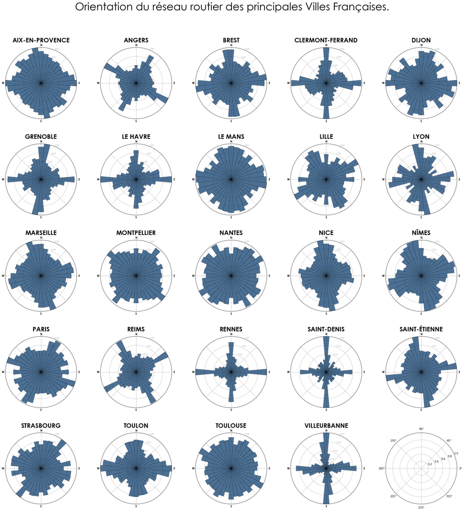

```python
n = len(places)
ncols = int(np.ceil(np.sqrt(n)))
nrows = int(np.ceil(n / ncols))
figsize = (ncols * 5, nrows * 5)
fig, axes = plt.subplots(nrows, ncols, figsize=figsize, subplot_kw={'projection':'polar'})

for ax, place in zip(axes.flat, sorted(places.keys())):
    polar_plot(ax, bearings[place].dropna(), title=place)

suptitle_font = {'family':'Century Gothic', 'fontsize':40, 'fontweight':'normal', 'y':1.07}
fig.suptitle('Orientation du réseau routier des principales Villes Françaises.', **suptitle_font)
fig.tight_layout()
fig.subplots_adjust(hspace=0.35)
plt.show()
```

Cette analyse nous permet d'explorer les similitudes et les différences entre les villes françaises. Notez qu'il existe des relations statistiques importantes entre l'ordre d'orientation de la ville, par exemple, en moyenne, les villes ont un schéma hétérogène de leurs orientations, bien que des villes comme Villeurbanne, Rennes, Saint-Denis et Clermont-Ferrand soient beaucoup plus quadrillées que les autres.

# Conclusions

Le réseau routier organise et limite la dynamique des transports dans la ville selon une certaine logique spatiale, planifiée ou non, ordonnée ou désordonnée.

Cette étude a présenté un modèle basé sur les algorithmes OSMnx pour l'optimisation des itinéraires cyclables potentiels en fonction de la longueur et de l'altitude du réseau routier en utilisant les données d'OpenStreetMap et de l'API GoogleMaps.

Enfin, le histogramme polaire des orientations a été visualisé pour découvrir pour la première fois la logique spatiale de la structure routière des principales Villes Françaises, montrant que les modèles sont une technique viable pour mesurer empiriquement et visualiser la complexité de l'ordre spatial, illustrant les modèles d'urbanisation et de transport.

Pour un affichage dynamique de l'algorithme [OSMnx](https://mourner.github.io/road-orientation-map/#12.26/48.84943/2.36378), il est possible de le trouver ici.

## 👍👍 [Partagez vos idées et vos commentaires, écrivez-moi 🌍](https://www.linkedin.com/in/lealrlx/)